# Celtic Seas

ICES 2024

[figure not shown]

**Information on the distribution, intensity, impact and economic value of mobile bottom contacting gear (MBCG) fisheries within the Celtic Seas area and associated subdivisions, and estimated consequences and costs (landings weight, landings value) of reducing their relative extent.**

## Celtic Seas

### Summary

**Geographic scope:** The assessment in this interactive document covers EU waters of depths shallower than 800 m in the MSFD subdivisions associated with the Celtic Seas area. EU waters are the waters defined by EU Member States, in this area, for MSFD implementation purposes (Figure E1).

**Spatial scales of analyses:** Analyses are presented by MSFD subdivision, MSFD broad habitat type (BHT) and for depth strata 0‒200 m, 200‒400 m, and 400‒800 m. The 0.05° × 0.05° c-squares (hereafter c-squares) were allocated to subdivisions based on centroid positions. Mean depths in c-squares were used to allocate c-squares to depth strata. For the Baltic Sea area, the subdivisions are as used in the ICES 2021 advice (ICES, 2021) and based on the HELCOM sub-basins (HELCOM, 2013). For the Greater North Sea, Celtic Seas and Bay of Biscay and the Iberian Coast areas, the subdivisions used are the OSPAR benthic habitat assessment area units (OSPAR, 2022), as used in the OSPAR 2023 Quality Status Report (OSPAR, 2023). The extent of BHTs, as defined under the MSFD, is determined per c-square.

Values of pressure indicators (I‒1 to I‒5) and impact indicators (I‒6a, I‒6b, I‒7a, and I‒7b) by depth strata (Table 1) provide information on the distribution, intensity, and impact of MBCG fisheries. The indicators are described in the “Essential information” tab in this document.

For depths of 0‒200 m, 56.4% of the area is fished with MBCG per year (I‒3). However, 90% of the total MBCG swept area is concentrated in an annual average of 41.3% of the Celtic Seas area. Thirteen point seven per cent of the area at these depths was not fished with MBCG at all from 2017‒2022, based on the data submissions received. For depths of 0‒200m, MBCG fishing was estimated to reduce the total biomass of benthic fauna by 6.5% (I‒6a) and reduce the total biomass of sensitive fauna by 9.3% (I‒6b). Within this depth strata, the depletion of benthic fauna was less than 20% in 94.1% (I‒7a) of the area. For sensitive fauna the corresponding area was 86.6% (I‒7b). The heterogeneous distributions of annual mean fishing intensity (swept area ratio [SAR]), annual mean total landings values (euros) and weight (kg), and seabed sensitivity (as estimated median longevity of the benthic fauna), are illustrated in Figure 1. The distributions of the fishing intensity and the seabed sensitivity account for the values of pressure and impact indicators reported in Table 1.

Small-scale fisheries, defined as vessels < 12 m in overall length deploying MBCG, operate in the Celtic Seas area as well. As these are not required to carry VMS by the EU Control Regulation (EU, 2009), their coverage in the VMS data submissions is unknown. The EU Fisheries Dependent Information (FDI) data does report on small-scale fisheries effort in kW × fishing days. However, the FDI reporting units differ from the subdivisions, BHTs, and depth strata used in these analyses. The correspondence between subdivisions and FDI reporting regions is illustrated in Figure E1. The incomplete data for small-scale fisheries results in underestimates of fishing intensity and impact, especially in inshore areas. In the Celtic Seas area the proportion of the total kW × fishing days of MBCG fishing attributed to small-scale fisheries (Table 2) varies from 0 - 33% between FAO regions.

**References:**

EU Council. 2009. Council Regulation (EC) No 1224/2009 of 20 November 2009 establishing a Community control system for ensuring compliance with the rules of the Common Fisheries Policy amending Regulations (EC) No 847/96, (EC) No 2371/2002, (EC) No 811/2004, (EC) No 768/2005, (EC) No 2115/2005, (EC) No 2166/2005, (EC) No 388/2006, (EC) No 509/2007, (EC) No 676/2007, (EC) No 1098/2007, (EC) No 1300/2008, (EC) No 1342/2008 and repealing Regulations (EEC) No 2847/93, (EC) No 1627/94 and (EC) No 1966/2006. Official Journal of the European Union L343, 1−50. http://data.europa.eu/eli/reg/2009/1224/oj

HELCOM. 2013. HELCOM Monitoring and Assessment Strategy. https://helcom.fi/wp-content/uploads/2020/02/Monitoring-and-assessment-strategy.pdf

ICES. 2021. ICES advice to the EU on how management scenarios to reduce mobile bottom fishing disturbance on seafloor habitats affect fisheries landing and value. In Report of the ICES Advisory Committee, 2021. ICES Advice 2021. sr.2021.08. https://doi.org/10.17895/ices.advice.8191

OSPAR. 2022. OSPAR Extent of Physical Disturbance to Benthic Habitats Assessment Units. https://odims.ospar.org/en/submissions/ospar_phys_dist_habs_au_2022_06/

OSPAR. 2023. OSPAR Quality Status Report. https://oap.ospar.org/en/ospar-assessments/quality-status-reports/qsr-2023/

#### Table 1

**Table 1. Values of pressure and impact indicators for 2017‒2022 for three depth strata in the Celtic Seas area. Values of I‒1, I‒2, I‒3, I‒4, I‒6a, I‒6b, I‒7a and I‒7b are annual means and I‒5 is evaluated over the six years. Descriptions of the pressure and impact indicators are provided in the ‘Essential Information’ Table E1 in this document.**

| Indicators | 0 to 200 m | 200 to 400 m | 400 to 800 m |
| --- | --- | --- | --- |
| I‒1: Average fishing intensity | 1.54 | 2.36 | 1.88 |
| I‒2: Proportion of area fished, evaluated at c-square scale (%) | 86.30 | 91.60 | 75.80 |
| I‒3: Proportion of area fished (%) | 56.40 | 72.50 | 47.30 |
| I‒4: Smallest proportion of area with 90% of fishing intensity, evaluated at c-square scale (%) | 41.30 | 51.40 | 32.50 |
| I‒5: Proportion of area persistently unfished, evaluated at c-square scale (%) | 13.70 | 8.40 | 24.20 |
| I‒6a: Average PD impact | 6.50 | 13.30 | 18.60 |
| I‒6b: Average PD-sens impact | 9.30 | 16.50 | 21.70 |
| I‒7a: Proportion of area with PD impact < 0.2, evaluated at c-square scale (%) | 94.10 | 76.40 | 70.80 |
| I‒7b: Proportion of area with PD-sens impact < 0.2, evaluated at c-square scale (%) | 86.60 | 67.00 | 67.70 |

#### Figure 1

**Figure 1. Geographic distribution of fishing intensity (swept area ratio), seabed sensitivity (community longevity), total landings value, and total landings weight from mobile bottom-contacting gear (MBCG) in the Celtic Seas area. The maps of swept area ratio, landings value, and landings weight show annual means evaluated at the c-square scale.**

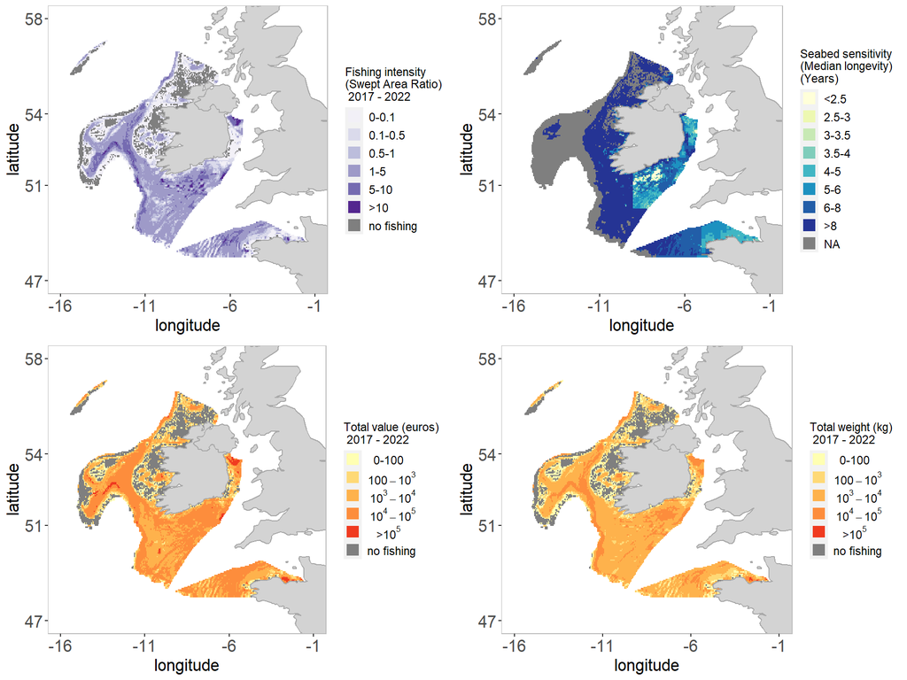

#### Table 2

**Table 2. Contribution of small-scale fisheries (vessels < 12 m overall length) to total fishing effort (kW × fishing days) in the Celtic Seas area. The table shows the total fishing effort (kW × fishing days) by FAO region over the assessment period, and the mean contribution (%) and observed range in contribution (%) of small-scale MBCG fisheries.**

| FAO region code | FAO region name | Total fishing effort (kW × Fishing days) | Mean contribution SSF (%) | Observed range SSF contribution (%) [min - max] |
| --- | --- | --- | --- | --- |
| 27.6.a | Northwest Coast of Scotland and North Ireland or as the west of Scotland | 2731463.0 | 0.0 | [0 - 0] |
| 27.6.b | Rockall | 748714.8 | 0.0 | [0 - 0] |
| 27.7.a | Irish Sea | 2532308.7 | 15.0 | [9 - 25] |
| 27.7.b | West of Ireland | 1297321.2 | 3.2 | [1 - 4] |
| 27.7.c | Porcupine Bank | 1490382.7 | 0.0 | [0 - 0] |
| 27.7.e | Eastern English Channel | 8267270.5 | 32.8 | [31 - 35] |
| 27.7.g | Celtic Sea North | 8563632.8 | 0.0 | [0 - 0] |
| 27.7.h | Celtic Sea South | 4749563.8 | 0.0 | [0 - 0] |
| 27.7.j | Southwest of Ireland - East | 5220065.7 | 0.2 | [0 - 1] |
| 27.7.k | Southwest of Ireland - West | 1726928.7 | 0.0 | [0 - 0] |

### Fishing intensity

The extent and relative abundance of BHTs in the Celtic Seas area are presented in Table 3. This table also presents landings weight and landings value and the intensity of MBCG fisheries operating in these habitats. Note that fishing data is only available at the c-square scale and is assumed to be uniformly distributed over all habitat types present in a c-square. Each habitat type present is proportionally assigned the fishing data registered in a c-square.

The most extensive habitat type is Offshore circalittoral sand occupying 55.42 ×1000 km<sup>2</sup> (20.7%). The average fishing intensity (swept area ratio) on this habitat is 1.89, covering annually on average 78.8% of the habitat extent. Ninety per cent of the fishing effort in this BHT however, is concentrated to 63.6% of the habitat extent. Two point per cent of this habitat is located in c squares that are persistently not fished. The largest landing (in tonnes) is derived from fishing on Upper bathyal sediment, and the greatest landings values come from fishing on Upper bathyal sediment.

Temporal variation of the pressure indicators I−1, I−3, and I−4 are shown in Figure 2 for the Celtic Seas area.

#### Table 3

**Table 3. Extent (in km<sup>2</sup> and %) of broad habitat types in the Celtic Seas area, and mean annual estimates of MBCG fishing intensity, landings weight, and landings value. In addition, estimates of the average annual proportion of the fished extent, the smallest proportion of the habitat extent affected by 90% of the fishing effort, and the proportion of extent persistently unfished are provided.**

| MSFD broad habitat type | Extent of habitat (×1000 km<sup>2</sup>) | Relative habitat extent (%) | Landings (×1000 tonnes) | Value (×10<sup>6</sup> euro) | Swept area (×1000 km<sup>2</sup>) | Average fishing intensity (I‒1) | Average annual extent fished (%) | Smallest proportion of extent with 90% of fishing effort (%) | Percentage extent persistently unfished (%) |
| --- | --- | --- | --- | --- | --- | --- | --- | --- | --- |
| Offshore circalittoral sand | 55.42 | 20.7 | 12.50 | 35.41 | 104.96 | 1.89 | 78.8 | 63.6 | 2.0 |
| Upper bathyal sediment | 54.71 | 20.4 | 18.43 | 61.50 | 127.84 | 2.34 | 65.3 | 45.8 | 13.9 |
| Offshore circalittoral coarse sediment | 51.99 | 19.4 | 10.95 | 35.40 | 92.21 | 1.77 | 54.2 | 39.3 | 15.5 |
| Offshore circalittoral mud | 31.98 | 11.9 | 10.86 | 35.22 | 81.63 | 2.55 | 85.9 | 65.1 | 1.7 |
| Unknown | 29.57 | 11.0 | 2.24 | 6.22 | 17.16 | 0.58 | 29.8 | 25.7 | 29.5 |
| Upper bathyal sediment or Upper bathyal rock and biogenic reef | 19.14 | 7.1 | 4.34 | 10.79 | 29.27 | 1.53 | 43.5 | 31.3 | 22.7 |
| Circalittoral coarse sediment | 7.47 | 2.8 | 2.02 | 4.85 | 3.23 | 0.43 | 14.2 | 12.9 | 32.2 |
| Offshore circalittoral mixed sediment | 4.11 | 1.5 | 0.08 | 0.23 | 0.31 | 0.07 | 5.6 | 24.7 | 34.2 |
| Circalittoral rock and biogenic reef | 3.85 | 1.4 | 0.23 | 0.70 | 0.84 | 0.22 | 13.8 | 30.9 | 28.3 |
| Offshore circalittoral rock and biogenic reef | 3.64 | 1.4 | 0.26 | 1.02 | 1.08 | 0.30 | 18.6 | 35.2 | 21.7 |
| Circalittoral sand | 2.98 | 1.1 | 0.45 | 1.34 | 1.73 | 0.58 | 19.3 | 18.4 | 22.9 |
| Circalittoral mud | 1.15 | 0.4 | 0.07 | 0.28 | 0.55 | 0.48 | 25.7 | 35.0 | 10.5 |
| Infralittoral rock and biogenic reef | 0.75 | 0.3 | 0.20 | 0.35 | 0.09 | 0.13 | 8.4 | 23.9 | 19.7 |
| Infralittoral sand | 0.64 | 0.2 | 0.73 | 1.84 | 1.11 | 1.75 | 53.3 | 39.0 | 9.1 |
| Infralittoral coarse sediment | 0.53 | 0.2 | 0.69 | 1.55 | 0.45 | 0.84 | 29.0 | 25.8 | 12.4 |
| Infralittoral mud | 0.15 | 0.1 | 0.01 | 0.04 | 0.01 | 0.06 | 4.8 | 19.8 | 35.2 |
| Circalittoral mixed sediment | 0.09 | 0.0 | 0.01 | 0.01 | 0.01 | 0.07 | 7.1 | 27.8 | 41.2 |
| Infralittoral mixed sediment | 0.08 | 0.0 | 0.03 | 0.18 | 0.01 | 0.07 | 7.3 | 36.4 | 33.6 |
| Lower bathyal sediment or Lower bathyal rock and biogenic reef | 0.02 | 0.0 | 0.00 | 0.00 | 0.00 | 0.20 | 17.9 | NA | 15.7 |
| Upper bathyal rock and biogenic reef | 0.02 | 0.0 | 0.00 | 0.00 | 0.00 | 0.16 | 15.6 | NA | 7.0 |
| Lower bathyal sediment | 0.01 | 0.0 | 0.00 | 0.00 | 0.00 | 0.30 | 29.8 | NA | 37.6 |

#### Figure 2

**Figure 2. Temporal variation of the pressure indicators I‒1, I‒3 and I‒4 in the Celtic Seas area. Descriptions of the pressure indicators are provided in the ‘Essential Information’ Table E1 in this document.**

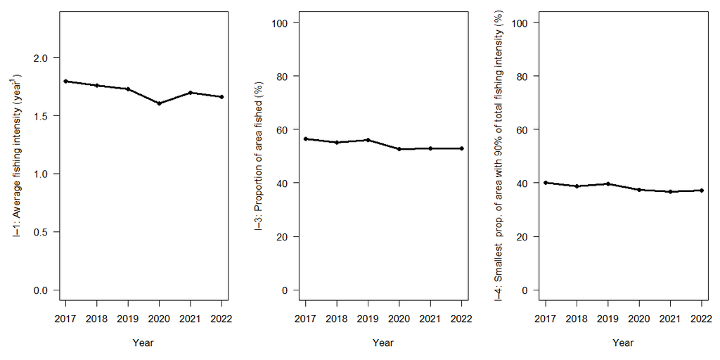

### Fishing by métier

Relationships between swept area and the landings weight and landings value of the métiers show the landings and economic returns as a function of swept area (Table 4). The most active métier within the Celtic Seas area is OT_DMF. This métier lands 128.36 kg of fish with a value of 357.49 euro per km<sup>2</sup> swept area.

The métier with the highest landing per swept area is OT_SPF, and the métier with the highest economic return per swept area is DRB_MOL.

#### Table 4

**Table 4. Landings weight and value by métier and their relationship with swept area in the Celtic Seas area.**

|  | OT_DMF | OT_CRU | SSC_DMF | OT_MI | TBB_DMF | DRB_MOL | SDN_DMF | OT_SPF |
| --- | --- | --- | --- | --- | --- | --- | --- | --- |
| Area swept (×1000 km<sup>2</sup>) | 348.82 | 52.23 | 48.60 | 7.77 | 3.91 | 0.76 | 0.49 | 0.15 |
| Landings (×1000 tonnes) | 44.77 | 6.36 | 2.89 | 1.76 | 2.89 | 4.12 | 0.03 | 1.27 |
| Value (×10<sup>6</sup> euro) | 124.70 | 38.01 | 6.46 | 6.15 | 10.42 | 10.69 | 0.07 | 0.41 |
| Landings / Area swept (kg/km<sup>2</sup>) | 128.36 | 121.70 | 59.42 | 226.46 | 740.62 | 5404.26 | 60.49 | 8605.37 |
| Value / Area swept (euro/km<sup>2</sup>) | 357.49 | 727.82 | 132.93 | 791.59 | 2666.32 | 14014.09 | 144.54 | 2758.03 |

### Core fishing grounds

Core fishing grounds are defined as the smallest area yielding 90% of the landings value, evaluated annually at the c-square scale. The spatial stability of core fishing grounds over the assessment period 2017−2022 is described as the number of years a c-square is identified as a core fishing ground. This spatial extent and stability of the core fishing grounds varies among métiers (Figures 3 and 4).

Overall, there is considerable variation in the stability of core fishing grounds among métiers. This is expected to be a consequence of interannual movements of fishing locations because of the habitat affinity of the variety of fish and shellfish targeted by different métiers (Table 5 in the main advice document) and the effects of economic and regulatory factors.

#### Figure 3

**Figure 3. Spatial stability of core MBCG fishing grounds, presented as the number of years a c-square is identified as a core fishing ground (smallest area yielding 90% of the landings value) per métier for the Celtic Seas area. Only métiers that were active within > 50 unique c-squares during the assessment period are included. The numbers between brackets show the proportion of fished extent compared to the overall assessed area extent.**

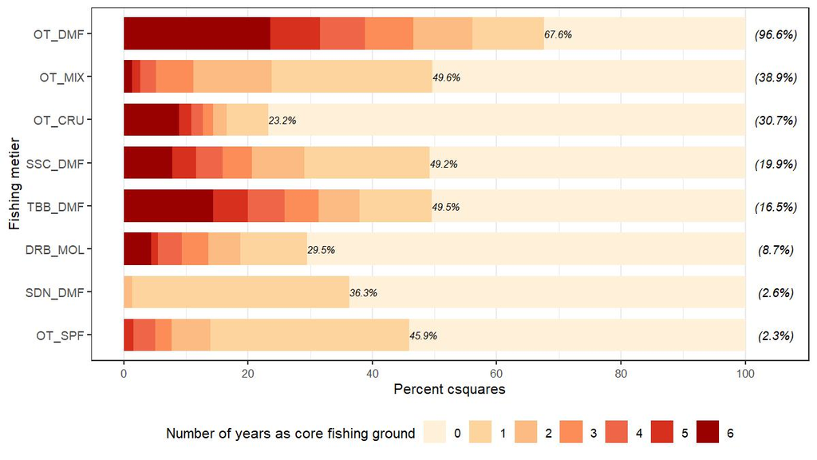

#### Figure 4

**Figure 4. Spatial distribution of the stability of the core MBCG fishing grounds, presented as the number of years a c-square is identified as a core fishing ground (smallest area yielding 90% of the landings value) per métier for the Celtic Seas area. Only métiers that were active within > 50 unique c-squares during the assessment period are included.**

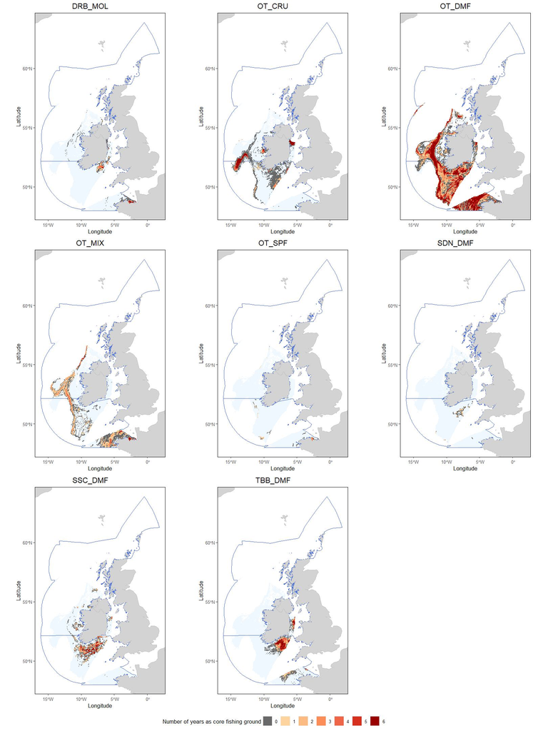

### Impact

Fishing impact, as assessed with the PD indicator (I−6a) and the PD-sens indicator (I−6b), results from the fishing intensity for MBCG métiers and the median longevity of the benthic fauna (Figure 1) as well as métier-specific depletion rates per trawl pass (Table 5 in the main advice document). The PD-sens indicator only considers sensitive fauna and shows greater impacts than the PD indicator (Figures 5 and 6).

For the OT_DMF métier, which accounts for the largest proportion of swept area (Table 4), landing weight is 50.4 tonnes and landings value 140300 euro per unit of PD impact. Similarly, landing weight is 39.4 tonnes and landings value 109800 per unit of PD-sens impact (Table 5). The métier with the highest landings weight per unit impact is OT_SPF (208.9 tonnes), and the métier with the highest landings value per unit impact is the SDN_DMF (266200 euros).

Métier-related impacts, as measured with the PD and PD-sens indicators, vary among BHTs because of variations in fishing intensity, seabed sensitivity (Figure 1), and the depletion rate of the specific métier (Table 5 in the main advice document; Figure 7). The largest PD and PD sens impacts in the Celtic Seas area are attributed to the OT_DMF métier fishing on Upper bathyal sediment.

#### Figure 5

**Figure 5. The spatial distribution of MBCG fisheries impact in the Celtic Seas area, as assessed with the PD indicator (I‒6a) and PD-sens indicator (I‒6b), shown as annual means for the assessment period, evaluated at the c-square scale. Descriptions of the impact indicators are provided in the ‘Essential Information’ Table E1 in this document.**

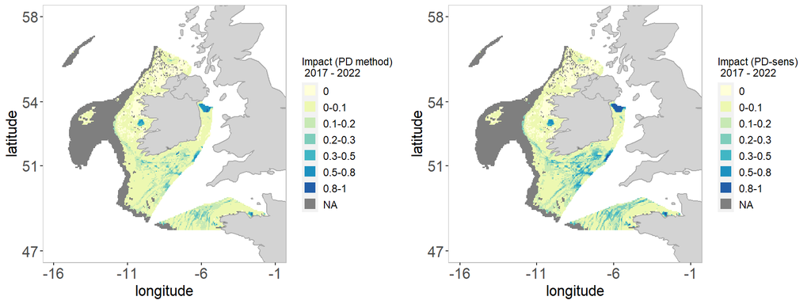

#### Figure 6

**Figure 6. Temporal variation in values of the PD indicator (I‒6a), PD-sens indicator (I‒6b), proportion of the extent with PD impact < 0.2 (I‒7a) and proportion of extent with PD-sens impact < 0.2 (I‒7b), shown for the overall area and for the four most extensive broad habitat types separately in the Celtic Seas area. Descriptions of the impact indicators are provided in the ‘Essential Information’ Table E1 in this document.**

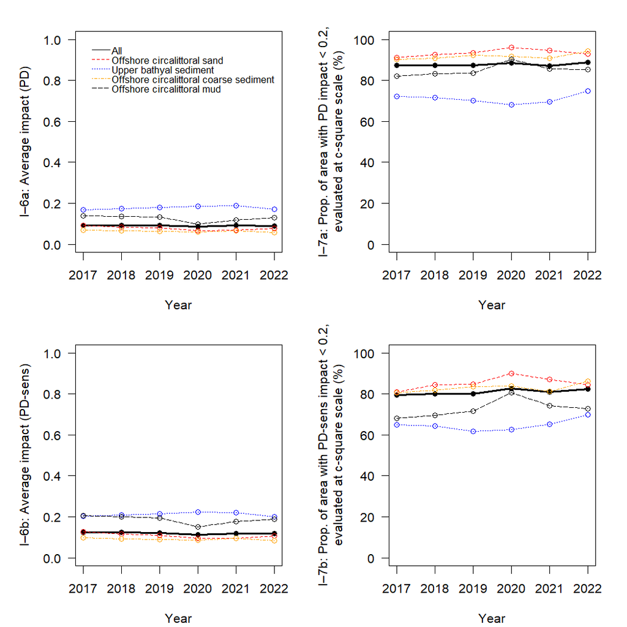

#### Table 5

**Table 5. Métier-specific landings weight and value per unit PD or PD-sens impact in the Celtic Seas area.**

|  | OT_DMF | OT_CRU | SSC_DMF | OT_MI | TBB_DMF | DRB_MOL | SDN_DMF | OT_SPF |
| --- | --- | --- | --- | --- | --- | --- | --- | --- |
| Landings (tonnes)/PD impact | 50.4 | 15.9 | 50.5 | 27.8 | 63.3 | 101.6 | 111.4 | 208.9 |
| Value (×1000 euro)/PD impact | 140.3 | 94.9 | 112.9 | 97.0 | 227.9 | 263.5 | 266.2 | 67.0 |
| Landings (tonnes)/PD-sens impact | 39.4 | 12.9 | 36.6 | 22.1 | 42.4 | 88.2 | 66.8 | 207.7 |
| Value (×1000 euro)/PD-sens impact | 109.8 | 77.1 | 81.9 | 77.3 | 152.8 | 228.6 | 159.5 | 66.6 |

#### Figure 7

**Figure 7. Métier-related impacts, reported as annual means of the PD indicator (I‒6a, top) and PD-sens indicator (I‒6b, bottom), on the four most extensive broad habitat types in the Celtic Seas area.**

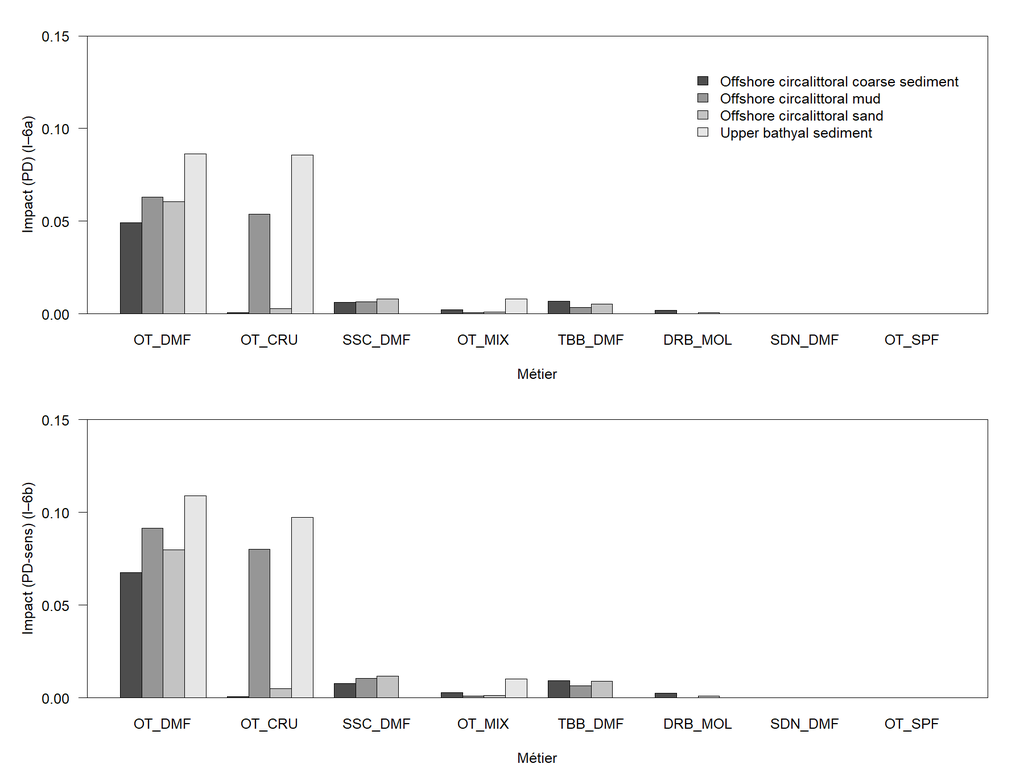

### Scenarios

#### Footprint reduction

The fishing footprint reduction scenarios illustrate the effects of stepwise MBCG fisheries exclusion from specified proportions of each BHT within the Celtic Seas area. The stepwise exclusion is conducted in 10% increments, ranging from 10% to 90%. In each successive increment, the c-squares containing the least MBCG swept area are excluded. The resulting reduction in swept area (Table 6), landings weight (Table 7), and landings value (Table 8) is presented for the prevailing BHTs combined and for each type separately.

For example, the analysis shows that the exclusion of MBCG from 30% of all prevailing BHTs types is affecting 4.0% of the footprint (Table 6), 7.3% of the landings weight (Table 7), and 6.6% of the landings value (Table 8). In this example, the pattern reflects the extent to which MBCG fishing activity is concentrated in core areas, with relatively low effort and landings in peripheral areas.

##### Table 6: Effort

**Table 6. The effects of stepwise exclusion of all MBCG fisheries from a specified proportion of a MSFD broad habitat type within the Celtic Seas area, on swept area (presented as % of total swept area within that habitat type). The stepwise exclusion is conducted in 10% increments, and within each successive increment from 10% to 90% the c-squares with the lowest recorded rank MBCG swept area are excluded. Note that the top row shows the total estimate for all habitats combined.**

| MSFD broad habitat type | Extent of habitat (×1000 km<sup>2</sup>) | Total area swept (×1000 km<sup>2</sup> | 10% | 20% | 30% | 40% | 50% | 60% | 70% | 80% | 90% |
| --- | --- | --- | --- | --- | --- | --- | --- | --- | --- | --- | --- |
| total | 268.3 | 100 | 0.3 | 1.6 | 4.0 | 7.7 | 12.9 | 20.5 | 31.2 | 45.8 | 65.9 |
| Offshore circalittoral sand | 55.42 | 104.96 | 0.4 | 2.8 | 6.9 | 12.6 | 19.7 | 28.2 | 38.8 | 51.7 | 68.5 |
| Upper bathyal sediment | 54.71 | 127.84 | <0.1 | 0.8 | 3.2 | 7.1 | 13.0 | 21.9 | 34.1 | 50.0 | 70.4 |
| Offshore circalittoral coarse sediment | 51.99 | 92.21 | <0.1 | 0.1 | 0.6 | 2.7 | 6.5 | 13.1 | 23.7 | 40.1 | 62.9 |
| Offshore circalittoral mud | 31.98 | 81.63 | 0.8 | 3.9 | 8.0 | 12.8 | 18.7 | 26.7 | 36.7 | 49.0 | 66.4 |
| Unknown | 29.57 | 17.16 | 0.0 | 0.0 | <0.1 | 0.4 | 1.1 | 2.9 | 10.6 | 26.7 | 53.6 |
| Upper bathyal sediment or Upper bathyal rock and biogenic reef | 19.14 | 29.27 | 0.0 | <0.1 | 0.2 | 0.6 | 2.4 | 7.7 | 18.6 | 36.2 | 62.5 |
| Circalittoral coarse sediment | 7.47 | 3.23 | 0.0 | 0.0 | 0.1 | 0.5 | 1.1 | 2.0 | 3.9 | 7.9 | 17.2 |
| Offshore circalittoral mixed sediment | 4.11 | 0.31 | 0.0 | 0.0 | 0.1 | 0.9 | 2.0 | 4.1 | 7.6 | 14.5 | 26.2 |
| Circalittoral rock and biogenic reef | 3.85 | 0.84 | 0.0 | 0.0 | 0.2 | 1.1 | 3.2 | 6.6 | 12.6 | 21.8 | 39.1 |
| Offshore circalittoral rock and biogenic reef | 3.64 | 1.08 | 0.0 | <0.1 | 0.6 | 1.9 | 4.4 | 8.6 | 15.1 | 25.3 | 41.3 |
| Circalittoral sand | 2.98 | 1.73 | 0.0 | <0.1 | 0.3 | 1.1 | 2.1 | 3.8 | 6.4 | 10.5 | 23.0 |
| Circalittoral mud | 1.15 | 0.55 | <0.1 | 0.5 | 1.5 | 3.3 | 5.5 | 9.0 | 13.6 | 21.1 | 41.6 |
| Infralittoral rock and biogenic reef | 0.75 | 0.09 | 0.0 | <0.1 | 0.2 | 0.8 | 1.4 | 3.4 | 7.5 | 13.2 | 33.4 |
| Infralittoral sand | 0.64 | 1.11 | <0.1 | <0.1 | 0.3 | 2.5 | 7.6 | 16.0 | 28.1 | 43.8 | 67.1 |
| Infralittoral coarse sediment | 0.53 | 0.45 | <0.1 | <0.1 | 0.3 | 0.7 | 2.0 | 3.2 | 9.9 | 21.1 | 41.6 |
| Infralittoral mud | 0.15 | 0.01 | 0.0 | 0.0 | 0.0 | 0.4 | 0.9 | 1.6 | 3.3 | 3.3 | 14.3 |
| Circalittoral mixed sediment | 0.09 | 0.01 | 0.0 | 0.0 | 0.0 | 1.0 | 4.0 | 6.7 | 26.1 | 26.1 | 100.0 |
| Infralittoral mixed sediment | 0.08 | 0.01 | 0.0 | 0.0 | 0.0 | 0.0 | 2.4 | 22.0 | 52.1 | 52.1 | 100.0 |
| Lower bathyal sediment or Lower bathyal rock and biogenic reef | 0.02 | 0 | 0.9 | 4.8 | 15.2 | 28.4 | 69.4 | 69.4 | 69.4 | 69.4 | 100.0 |
| Upper bathyal rock and biogenic reef | 0.02 | 0 | 1.2 | 1.2 | 4.5 | 4.5 | 6.4 | 12.1 | 28.2 | 38.5 | 58.9 |
| Lower bathyal sediment | 0.01 | 0 | 4.1 | 4.1 | 24.0 | 24.0 | 100.0 | 100.0 | 100.0 | 100.0 | 100.0 |

##### Table 7: Landings weight

**Table 7. The effects of stepwise exclusion of all MBCG fisheries from a specified proportion of a MSFD broad habitat type within the Celtic Seas area, on landings weight (presented as % of total landings weight within that habitat type). The stepwise exclusion is conducted in 10% increments, and within each successive increment from 10% to 90% the c-squares with the lowest recorded rank MBCG swept area are excluded. Note that the top row shows the total estimate for all habitats combined.**

| MSFD broad habitat type | Extent of habitat (×1000 km<sup>2</sup>) | Total landings weight (×1000 kg) | 10% | 20% | 30% | 40% | 50% | 60% | 70% | 80% | 90% |
| --- | --- | --- | --- | --- | --- | --- | --- | --- | --- | --- | --- |
| Total | 268.3 | 62665.4 | 0.6 | 3.2 | 7.3 | 12.4 | 18.8 | 27.0 | 37.6 | 51.1 | 69.0 |
| Offshore circalittoral sand | 55.42 | 12495.3 | 1.2 | 7.5 | 16.0 | 23.5 | 31.9 | 41.5 | 51.9 | 64.0 | 78.4 |
| Upper bathyal sediment | 54.71 | 17400.4 | 0.6 | 2.9 | 6.7 | 12.4 | 19.5 | 29.3 | 40.9 | 55.3 | 72.4 |
| Offshore circalittoral coarse sediment | 51.99 | 10936.1 | <0.1 | 0.5 | 2.9 | 8.3 | 15.5 | 23.9 | 36.1 | 51.5 | 71.7 |
| Offshore circalittoral mud | 31.98 | 10860.6 | 1.1 | 4.8 | 9.6 | 15.1 | 21.2 | 29.0 | 38.7 | 50.3 | 65.7 |
| Unknown | 29.57 | 2227.7 | 0.0 | 0.0 | 0.2 | 0.7 | 1.9 | 5.6 | 13.9 | 29.8 | 55.9 |
| Upper bathyal sediment or Upper bathyal rock and biogenic reef | 19.14 | 4250 | 0.0 | <0.1 | 0.1 | 0.6 | 2.5 | 8.0 | 19.1 | 37.0 | 63.4 |
| Circalittoral coarse sediment | 7.47 | 2009.4 | 0.0 | 0.0 | 0.1 | 0.8 | 1.9 | 3.2 | 5.4 | 14.3 | 26.8 |
| Offshore circalittoral mixed sediment | 4.11 | 54.6 | 0.0 | 0.0 | 0.3 | 1.8 | 3.6 | 12.3 | 18.5 | 27.1 | 43.5 |
| Circalittoral rock and biogenic reef | 3.85 | 220.4 | 0.0 | 0.0 | 1.0 | 2.5 | 7.3 | 15.4 | 23.8 | 37.0 | 55.1 |
| Offshore circalittoral rock and biogenic reef | 3.64 | 262 | 0.0 | <0.1 | 1.0 | 2.9 | 6.5 | 10.5 | 18.8 | 27.9 | 49.6 |
| Circalittoral sand | 2.98 | 434.8 | 0.0 | 0.4 | 1.8 | 4.0 | 9.0 | 12.4 | 16.6 | 21.6 | 38.8 |
| Circalittoral mud | 1.15 | 68.7 | 0.3 | 2.3 | 4.3 | 6.7 | 9.7 | 21.1 | 27.3 | 37.1 | 56.6 |
| Infralittoral rock and biogenic reef | 0.75 | 145 | 0.0 | <0.1 | 1.0 | 2.2 | 2.2 | 3.2 | 7.3 | 18.6 | 41.2 |
| Infralittoral sand | 0.64 | 626 | <0.1 | 0.3 | 1.4 | 8.1 | 14.1 | 21.1 | 34.7 | 47.5 | 74.0 |
| Infralittoral coarse sediment | 0.53 | 657.2 | <0.1 | 0.1 | 0.5 | 1.3 | 4.5 | 7.1 | 17.0 | 27.9 | 54.0 |
| Infralittoral mud | 0.15 | 5.9 | 0.0 | 0.0 | 0.0 | 6.8 | 8.6 | 8.7 | 19.7 | 19.7 | 54.2 |
| Circalittoral mixed sediment | 0.09 | 8.3 | 0.0 | 0.0 | 0.0 | 0.2 | 0.4 | 0.8 | 65.2 | 65.2 | 100.0 |
| Infralittoral mixed sediment | 0.08 | 1.4 | 0.0 | 0.0 | 0.0 | 0.0 | <0.1 | 1.5 | 97.6 | 97.6 | 100.0 |
| Lower bathyal sediment or Lower bathyal rock and biogenic reef | 0.02 | 0.6 | 0.8 | 4.8 | 15.3 | 23.6 | 69.5 | 69.5 | 69.5 | 69.5 | 100.0 |
| Upper bathyal rock and biogenic reef | 0.02 | 0.3 | 1.6 | 1.6 | 4.5 | 4.5 | 6.4 | 20.4 | 37.3 | 46.4 | 67.7 |
| Lower bathyal sediment | 0.01 | 0.6 | 2.7 | 2.7 | 24.1 | 24.1 | 100.0 | 100.0 | 100.0 | 100.0 | 100.0 |

##### Table 8: Landings value

**Table 8. The effects of stepwise exclusion of all MBCG fisheries from a specified proportion of a MSFD broad habitat type within the Celtic Seas area, on landings value (presented as % of total landings value within that habitat type). The stepwise exclusion is conducted in 10% increments, and within each successive increment from 10% to 90% the c-squares with the lowest recorded rank MBCG swept area are excluded. Note that the top row shows the total estimate for all habitats combined.**

| MSFD broad habitat type | Extent of habitat (×1000 km<sup>2</sup>) | Total landings value (×1000 euro) | 10% | 20% | 30% | 40% | 50% | 60% | 70% | 80% | 90% |
| --- | --- | --- | --- | --- | --- | --- | --- | --- | --- | --- | --- |
| Total | 268.3 | 195713.6 | 0.4 | 3.0 | 6.6 | 11.9 | 18.6 | 26.7 | 36.7 | 49.8 | 68.0 |
| Offshore circalittoral sand | 55.42 | 35401.5 | 1.3 | 8.3 | 15.6 | 23.0 | 31.1 | 39.9 | 49.4 | 61.4 | 76.9 |
| Upper bathyal sediment | 54.71 | 61137.9 | <0.1 | 2.0 | 5.6 | 9.7 | 17.2 | 27.3 | 38.0 | 51.7 | 71.1 |
| Offshore circalittoral coarse sediment | 51.99 | 35340.7 | <0.1 | 0.5 | 2.5 | 9.1 | 17.9 | 26.7 | 38.9 | 53.9 | 73.0 |
| Offshore circalittoral mud | 31.98 | 35202.4 | 0.9 | 4.1 | 8.5 | 15.7 | 21.5 | 27.9 | 36.3 | 46.9 | 62.2 |
| Unknown | 29.57 | 6187.8 | 0.0 | 0.0 | 0.2 | 0.8 | 2.2 | 5.8 | 14.1 | 28.4 | 52.2 |
| Upper bathyal sediment or Upper bathyal rock and biogenic reef | 19.14 | 10754.5 | 0.0 | <0.1 | 0.2 | 0.9 | 2.8 | 8.1 | 19.3 | 36.7 | 61.7 |
| Circalittoral coarse sediment | 7.47 | 4824.3 | 0.0 | 0.0 | 0.2 | 0.8 | 1.7 | 2.9 | 5.3 | 13.4 | 26.1 |
| Offshore circalittoral mixed sediment | 4.11 | 149.8 | 0.0 | 0.0 | 0.4 | 1.9 | 3.7 | 12.1 | 16.9 | 25.7 | 39.9 |
| Circalittoral rock and biogenic reef | 3.85 | 676.6 | 0.0 | 0.0 | 0.8 | 2.4 | 5.7 | 13.6 | 23.6 | 34.1 | 53.4 |
| Offshore circalittoral rock and biogenic reef | 3.64 | 1012.5 | 0.0 | <0.1 | 1.0 | 2.8 | 5.6 | 9.0 | 16.5 | 25.6 | 49.6 |
| Circalittoral sand | 2.98 | 1319.5 | 0.0 | 0.2 | 0.9 | 2.8 | 4.7 | 7.6 | 11.3 | 17.6 | 32.0 |
| Circalittoral mud | 1.15 | 279.2 | 0.2 | 1.0 | 2.7 | 5.3 | 8.1 | 16.1 | 22.8 | 34.7 | 51.0 |
| Infralittoral rock and biogenic reef | 0.75 | 312.5 | 0.0 | <0.1 | 0.2 | 0.8 | 1.0 | 2.4 | 6.2 | 15.1 | 40.5 |
| Infralittoral sand | 0.64 | 1595.5 | <0.1 | 0.2 | 1.1 | 7.4 | 13.9 | 20.6 | 33.3 | 47.8 | 72.9 |
| Infralittoral coarse sediment | 0.53 | 1480.5 | <0.1 | <0.1 | 0.3 | 1.2 | 4.7 | 7.6 | 18.0 | 30.6 | 53.5 |
| Infralittoral mud | 0.15 | 13.9 | 0.0 | 0.0 | 0.0 | 3.2 | 6.0 | 6.2 | 17.9 | 17.9 | 42.5 |
| Circalittoral mixed sediment | 0.09 | 14 | 0.0 | 0.0 | 0.0 | 0.4 | 0.9 | 2.3 | 44.7 | 44.7 | 100.0 |
| Infralittoral mixed sediment | 0.08 | 5.4 | 0.0 | 0.0 | 0.0 | 0.0 | <0.1 | 1.8 | 97.3 | 97.3 | 100.0 |
| Lower bathyal sediment or Lower bathyal rock and biogenic reef | 0.02 | 2.1 | 0.9 | 4.6 | 13.8 | 22.8 | 71.8 | 71.8 | 71.8 | 71.8 | 100.0 |
| Upper bathyal rock and biogenic reef | 0.02 | 1.2 | 1.4 | 1.4 | 4.6 | 4.6 | 6.4 | 15.5 | 31.4 | 41.0 | 62.4 |
| Lower bathyal sediment | 0.01 | 2 | 2.6 | 2.6 | 23.7 | 23.7 | 100.0 | 100.0 | 100.0 | 100.0 | 100.0 |

#### Gear modifications

The effects of hypothetical gear modifications or changes in fishing practices were expressed in terms of their effects on the depletion of benthic fauna per gear pass. It was assumed that the modifications or changes in practice would achieve 5%, 10%, or 20% less depletion per gear pass. The effects of these changes in depletion on the quality and extent of the four BHTs that account for the greatest proportion of the Celtic Seas area are presented in figures 8−11. Impacts of MBCG were calculated as changes in habitat “quality” (measured as 1-PD impact or 1-PD-sens impact) in the fished area and expressed in terms of the increase in the quality of habitat meeting the extent threshold (> 75% of a BHT not adversely affected [EC, 2024]).

**References:**

EC. 2024. Commission Notice C/2024/2078 on the threshold values set under the Marine Strategy Framework Directive 2008/56/EC and Commission Decision (EU) 2017/848). Official Journal of the European Union C/2024/2078, 5pp. http://data.europa.eu/eli/C/2024/2078/oj

##### Figure 8: Habitat 1

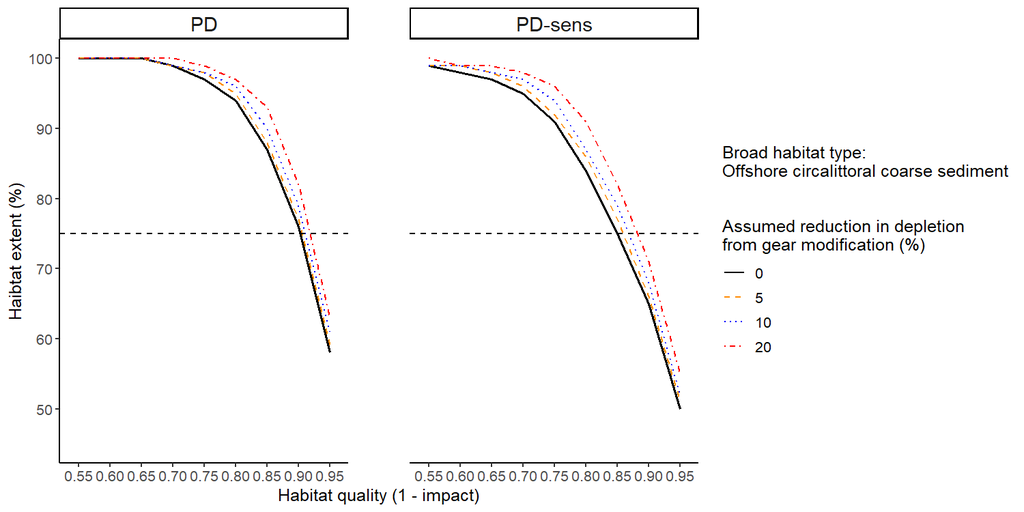

##### Figure 9: Habitat 2

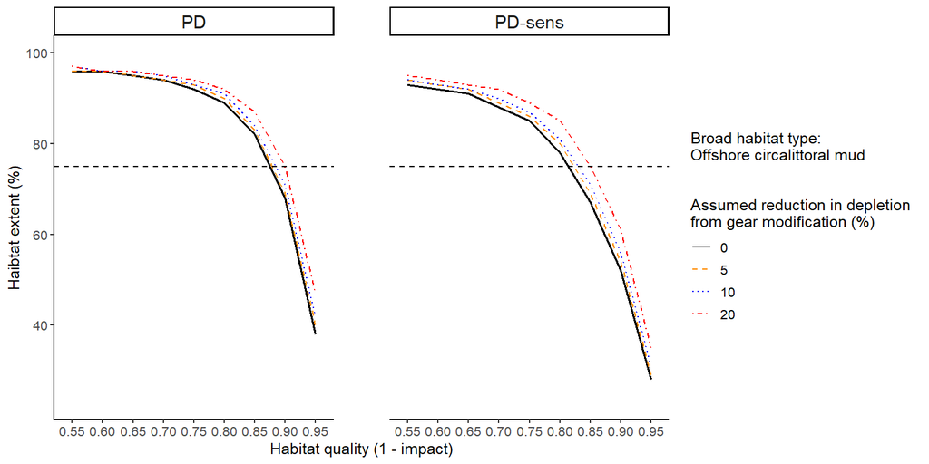

##### Figure 10: Habitat 3

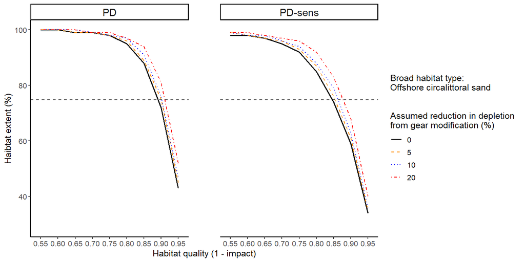

##### Figure 11: Habitat 4

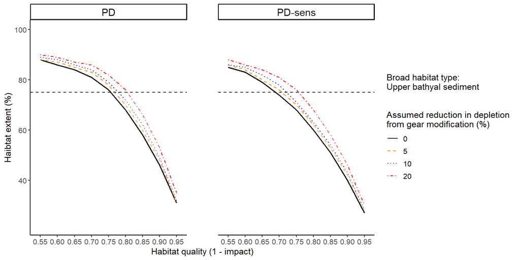

## Northern Celtic Sea

### Summary

#### Table 1

**Table 1. Values of pressure and impact indicators for 2017‒2022 for three depth strata in the Northern Celtic Sea subdivision. Values of I‒1, I‒2, I‒3, I‒4, I‒6a, I‒6b, I‒7a and I‒7b are annual means and I‒5 is evaluated over the six years. Descriptions of the pressure and impact indicators are provided in the ‘Essential Information’ Table E1 in this document.**

| Indicators | 0 to 200 m | 200 to 400 m | 400 to 800 m |
| --- | --- | --- | --- |
| I‒1: Average fishing intensity | 0.44 | 2.01 | 1.95 |
| I‒2: Proportion of area fished, evaluated at c-square scale (%) | 65.50 | 89.40 | 71.00 |
| I‒3: Proportion of area fished (%) | 16.70 | 66.30 | 47.00 |
| I‒4: Smallest proportion of area with 90% of fishing intensity, evaluated at c-square scale (%) | 13.20 | 47.20 | 32.10 |
| I‒5: Proportion of area persistently unfished, evaluated at c-square scale (%) | 34.50 | 10.60 | 29.00 |
| I‒6a: Average PD impact | 2.90 | 11.20 | 18.60 |
| I‒6b: Average PD-sens impact | 4.10 | 13.90 | 21.30 |
| I‒7a: Proportion of area with PD impact < 0.2, evaluated at c-square scale (%) | 96.60 | 79.60 | 72.90 |
| I‒7b: Proportion of area with PD-sens impact < 0.2, evaluated at c-square scale (%) | 95.50 | 71.80 | 69.60 |

#### Figure 1

**Figure 1. Geographic distribution of fishing intensity (swept area ratio), seabed sensitivity (community longevity), total landings value, and total landings weight from mobile bottom-contacting gear (MBCG) in the Northern Celtic Sea subdivision. The maps of swept area ratio, landings value, and landings weight show annual means evaluated at the c-square scale.**

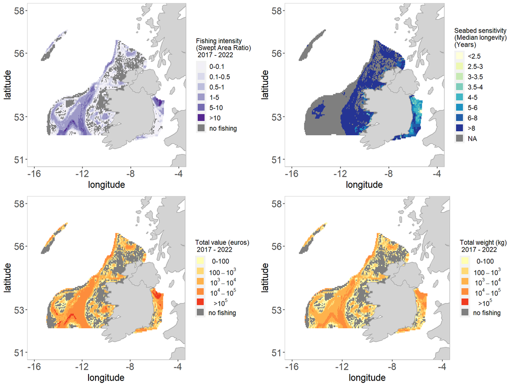

#### Table 2

**Table 2. Contribution of small-scale fisheries (vessels < 12 m overall length) to total fishing effort (kW × fishing days) in the Northern Celtic Sea subdivision. The table shows the total fishing effort (kW × fishing days) by FAO region over the assessment period, and the mean contribution (%) and observed range in contribution (%) of small-scale MBCG fisheries’.**

| FAO region code | FAO region name | Total fishing effort (kW × Fishing days) | Mean contribution SSF (%) | Observed range SSF contribution (%) [min - max] |
| --- | --- | --- | --- | --- |

### Fishing intensity

#### Table 3

**Table 3. Extent (in km<sup>2</sup> and %) of broad habitat types in the Northern Celtic Sea subdivision, and mean annual estimates of MBCG fishing intensity, landings weight, and landings value. In addition, estimates of the average annual proportion of the fished extent, the smallest proportion of the habitat extent affected by 90% of the fishing effort, and the proportion of extent persistently unfished are provided.**

| MSFD broad habitat type | Extent of habitat (×1000 km<sup>2</sup>) | Relative habitat extent (%) | Landings (×1000 tonnes) | Value (×10<sup>6</sup> euro) | Swept area (×1000 km<sup>2</sup>) | Average fishing intensity (I‒1) | Average annual extent fished (%) | Smallest proportion of extent with 90% of fishing effort (%) | Percentage extent persistently unfished (%) |
| --- | --- | --- | --- | --- | --- | --- | --- | --- | --- |
| Upper bathyal sediment | 43.39 | 36.4 | 13.68 | 43.77 | 87.86 | 2.03 | 61.3 | 43.0 | 16.3 |
| Unknown | 23.75 | 19.9 | 0.93 | 2.75 | 7.06 | 0.30 | 16.0 | 15.9 | 36.4 |
| Offshore circalittoral coarse sediment | 18.43 | 15.4 | 0.76 | 1.99 | 1.19 | 0.06 | 5.0 | 19.1 | 43.4 |
| Offshore circalittoral sand | 7.53 | 6.3 | 1.37 | 3.37 | 3.53 | 0.47 | 31.5 | 38.0 | 14.2 |
| Offshore circalittoral mud | 6.98 | 5.9 | 3.42 | 13.31 | 20.15 | 2.89 | 60.6 | 40.5 | 7.8 |
| Circalittoral coarse sediment | 4.34 | 3.6 | 0.13 | 0.27 | 0.16 | 0.04 | 3.1 | 20.0 | 54.2 |
| Offshore circalittoral mixed sediment | 4.00 | 3.4 | 0.05 | 0.11 | 0.14 | 0.04 | 3.6 | 35.4 | 35.1 |
| Upper bathyal sediment or Upper bathyal rock and biogenic reef | 3.34 | 2.8 | 0.59 | 2.07 | 3.78 | 1.13 | 33.9 | 24.7 | 27.2 |
| Offshore circalittoral rock and biogenic reef | 2.14 | 1.8 | 0.08 | 0.21 | 0.15 | 0.07 | 5.3 | 30.7 | 35.9 |
| Circalittoral sand | 2.08 | 1.7 | 0.13 | 0.28 | 0.28 | 0.13 | 12.0 | 30.6 | 30.8 |
| Circalittoral rock and biogenic reef | 2.08 | 1.7 | 0.11 | 0.29 | 0.21 | 0.10 | 8.8 | 24.4 | 46.9 |
| Circalittoral mud | 0.66 | 0.6 | 0.02 | 0.07 | 0.09 | 0.14 | 12.9 | 49.0 | 13.7 |
| Infralittoral sand | 0.14 | 0.1 | 0.01 | 0.02 | 0.00 | 0.02 | 2.3 | 40.3 | 27.0 |
| Infralittoral rock and biogenic reef | 0.12 | 0.1 | 0.00 | 0.01 | 0.01 | 0.08 | 8.2 | 26.8 | 35.1 |
| Infralittoral coarse sediment | 0.10 | 0.1 | 0.00 | 0.01 | 0.00 | 0.04 | 3.5 | 42.2 | 30.5 |
| Circalittoral mixed sediment | 0.09 | 0.1 | 0.01 | 0.01 | 0.01 | 0.07 | 7.0 | 27.0 | 41.3 |
| Infralittoral mud | 0.09 | 0.1 | 0.00 | 0.01 | 0.00 | 0.02 | 2.5 | 26.4 | 43.6 |
| Infralittoral mixed sediment | 0.03 | 0.0 | 0.00 | 0.00 | 0.00 | 0.01 | 1.4 | NA | 82.4 |
| Lower bathyal sediment | 0.01 | 0.0 | 0.00 | 0.00 | 0.00 | 0.33 | 33.3 | NA | 43.8 |
| Upper bathyal rock and biogenic reef | 0.00 | 0.0 | 0.00 | 0.00 | 0.00 | 0.05 | 5.1 | NA | 60.1 |

#### Figure 2

**Figure 2. Temporal variation of the pressure indicators I‒1, I‒3 and I‒4 in the Northern Celtic Sea subdivision. Descriptions of the pressure indicators are provided in the ‘Essential Information’ Table E1 in this document.**

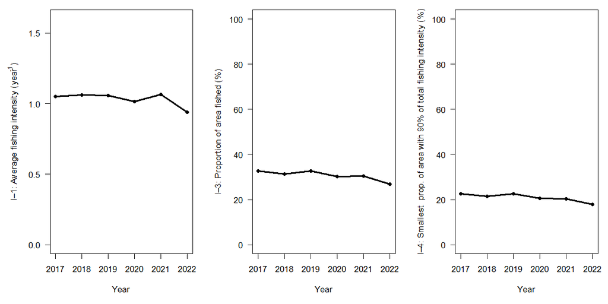

### Fishing by métier

#### Table 4

**Table 4. Landings weight and value by métier and their relationship with swept area in the Northern Celtic Sea subdivision.**

|  | OT_DMF | OT_CRU | SSC_DMF | OT_MI | TBB_DMF | DRB_MOL |
| --- | --- | --- | --- | --- | --- | --- |
| Area swept (×1000 km<sup>2</sup>) | 88.09 | 30.32 | 3.06 | 2.56 | 0.55 | 0.08 |
| Landings (×1000 tonnes) | 13.80 | 4.15 | 0.37 | 0.53 | 0.58 | 0.63 |
| Value (×10<sup>6</sup> euro) | 39.29 | 23.21 | 0.66 | 1.87 | 2.31 | 0.93 |
| Landings / Area swept (kg/km<sup>2</sup>) | 156.66 | 136.81 | 121.42 | 205.46 | 1052.37 | 7574.58 |
| Value / Area swept (euro/km<sup>2</sup>) | 446.02 | 765.71 | 214.37 | 728.40 | 4201.74 | 11187.06 |

### Core fishing grounds

#### Figure 3

**Figure 3. Spatial stability of core MBCG fishing grounds, presented as the number of years a c-square is identified as a core fishing ground (smallest area yielding 90% of the landings value) per métier for the Northern Celtic Sea subdivision. Only métiers that were active within > 50 unique c-squares during the assessment period are included. The numbers between brackets show the proportion of fished extent compared to the overall assessed area extent.**

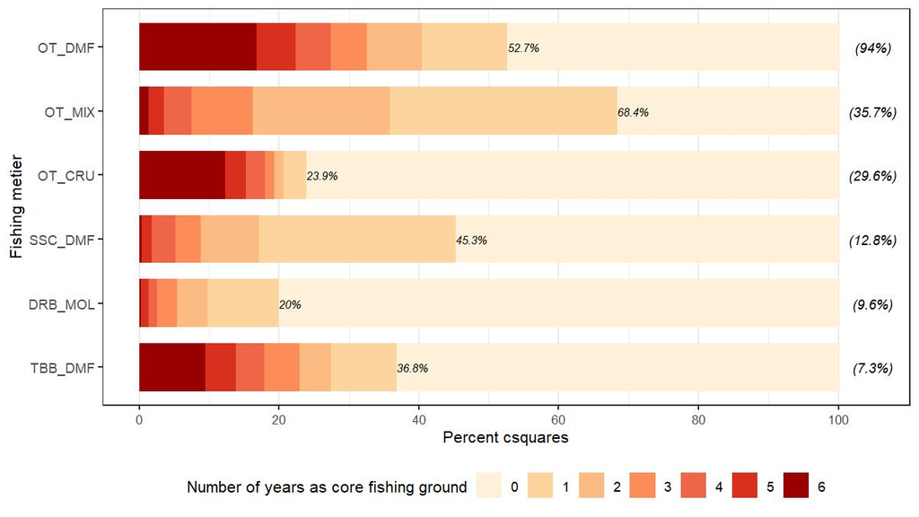

#### Figure 4

**Figure 4. Spatial distribution of the stability of the core MBCG fishing grounds, presented as the number of years a c-square is identified as a core fishing ground (smallest area yielding 90% of the landings value) per métier for the Northern Celtic Sea subdivision. Only métiers that were active within > 50 unique c-squares during the assessment period are included.**

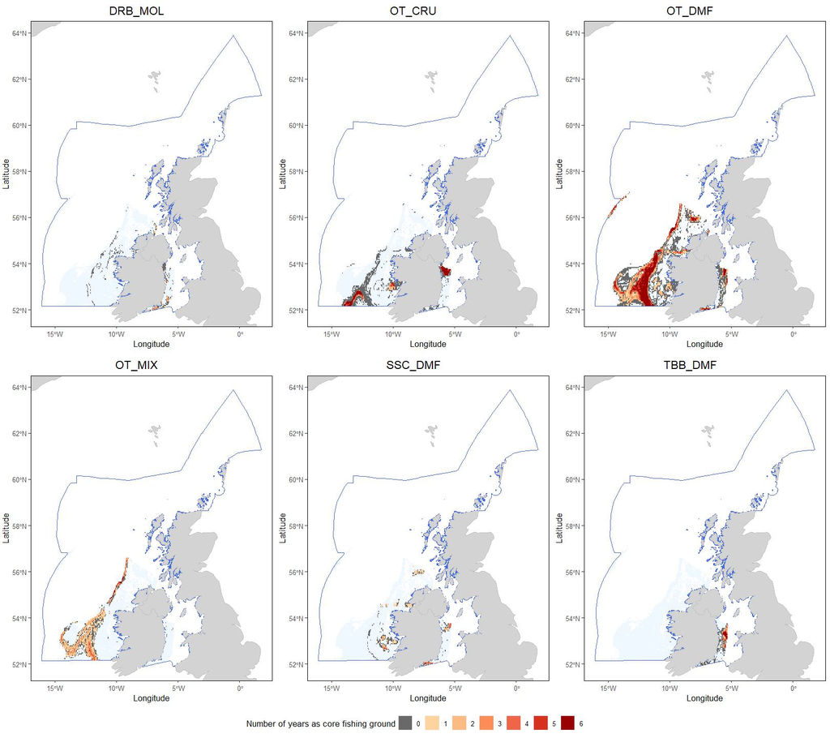

### Impact

#### Figure 5

**Figure 5. The spatial distribution of MBCG fisheries impact in the Northern Celtic Sea subdivision, as assessed with the PD indicator (I‒6a) and PD-sens indicator (I‒6b), shown as annual means for the assessment period, evaluated at the c-square scale. Descriptions of the impact indicators are provided in the ‘Essential Information’ Table E1 in this document.**

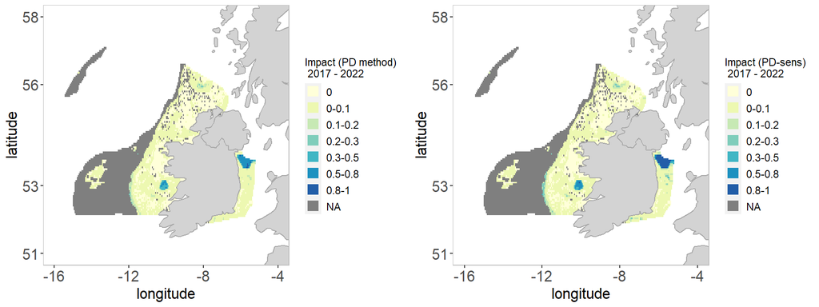

#### Figure 6

**Figure 6. Temporal variation in values of the PD indicator (I‒6a), PD-sens indicator (I‒6b), proportion of the extent with PD impact < 0.2 (I‒7a) and proportion of extent with PD-sens impact < 0.2 (I‒7b), shown for the overall area and for the four most extensive broad habitat types separately in the Northern Celtic Sea subdivision. Descriptions of the impact indicators are provided in the ‘Essential Information’ Table E1 in this document.**

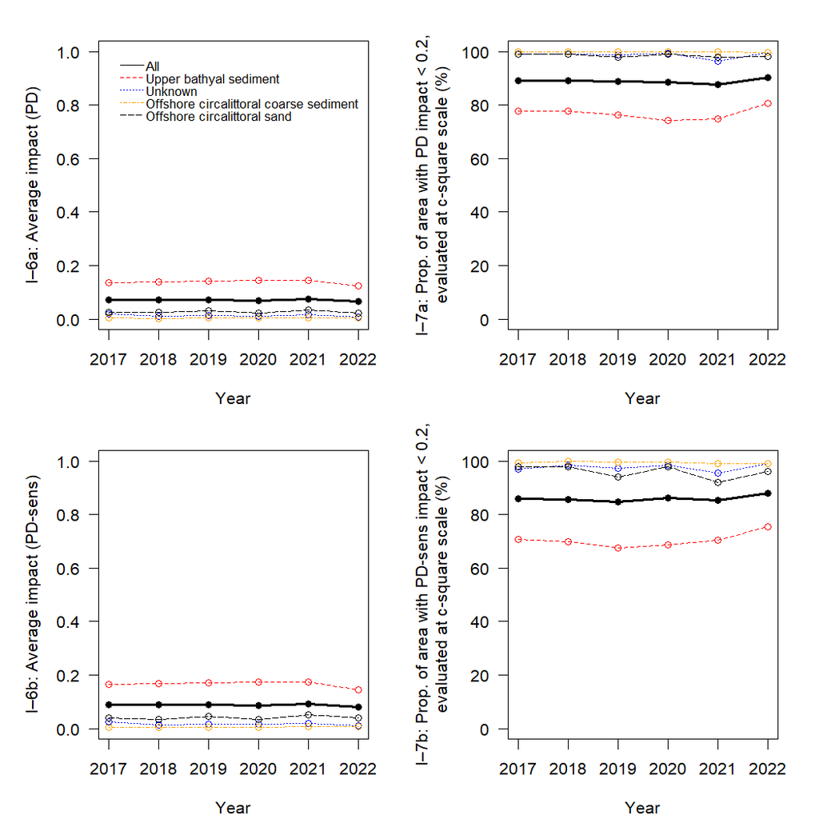

#### Table 5

**Table 5. Métier-specific landings weight and value per unit PD or PD-sens impact in the Northern Celtic Sea subdivision.**

|  | OT_DMF | OT_CRU | SSC_DMF | OT_MI | TBB_DMF | DRB_MOL |
| --- | --- | --- | --- | --- | --- | --- |
| Landings (tonnes)/PD impact | 41.6 | 19.8 | 57.3 | 18.7 | 75.8 | 57.1 |
| Value (×1000 euro)/PD impact | 118.3 | 110.9 | 101.2 | 66.1 | 302.5 | 84.3 |
| Landings (tonnes)/PD-sens impact | 34.8 | 16.3 | 44.6 | 15.3 | 53.1 | 53.0 |
| Value (×1000 euro)/PD-sens impact | 99.1 | 91.0 | 78.7 | 54.4 | 212.2 | 78.3 |

#### Figure 7

**Figure 7. Métier-related impacts, reported as annual means of the PD indicator (I‒6a, top) and PD-sens indicator (I‒6b, bottom), on the four most extensive broad habitat types in the Northern Celtic Sea subdivision.**

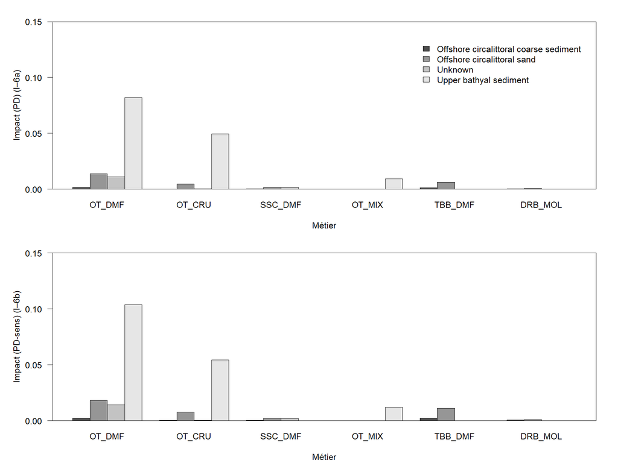

### Scenarios

#### Footprint reduction

##### Table 6: Effort

**Table 6. The effects of stepwise exclusion of all MBCG fisheries from a specified proportion of a MSFD broad habitat type within the Northern Celtic Sea subdivision, on swept area (presented as % of total swept area within that habitat type). The stepwise exclusion is conducted in 10% increments, and within each successive increment from 10% to 90% the c-squares with the lowest recorded rank MBCG swept area are excluded. Note that the top row shows the total estimate for all habitats combined.**

| MSFD broad habitat type | Extent of habitat (×1000 km<sup>2</sup>) | Total area swept (×1000 km<sup>2</sup> | 10% | 20% | 30% | 40% | 50% | 60% | 70% | 80% | 90% |
| --- | --- | --- | --- | --- | --- | --- | --- | --- | --- | --- | --- |
| total | 119.3 | 100 | <0.1 | 0.5 | 2.1 | 5.1 | 9.6 | 16.4 | 26.5 | 41.0 | 63.3 |
| Upper bathyal sediment | 43.39 | 87.86 | <0.1 | 0.7 | 2.8 | 6.7 | 12.0 | 19.9 | 31.1 | 46.9 | 68.5 |
| Unknown | 23.75 | 7.06 | 0.0 | 0.0 | <0.1 | 0.2 | 0.7 | 1.6 | 3.5 | 9.4 | 27.7 |
| Offshore circalittoral coarse sediment | 18.43 | 1.19 | 0.0 | 0.0 | 0.0 | 0.5 | 1.8 | 3.9 | 6.8 | 11.8 | 23.3 |
| Offshore circalittoral sand | 7.53 | 3.53 | 0.0 | 0.3 | 0.9 | 2.3 | 5.4 | 10.5 | 18.8 | 31.5 | 53.0 |
| Offshore circalittoral mud | 6.98 | 20.15 | <0.1 | 0.1 | 0.5 | 1.9 | 5.1 | 11.2 | 20.5 | 34.0 | 60.6 |
| Circalittoral coarse sediment | 4.34 | 0.16 | 0.0 | 0.0 | 0.0 | 0.0 | 0.9 | 3.2 | 7.3 | 14.0 | 25.6 |
| Offshore circalittoral mixed sediment | 4 | 0.14 | 0.0 | 0.0 | 0.2 | 1.7 | 4.2 | 8.2 | 14.7 | 26.5 | 45.3 |
| Upper bathyal sediment or Upper bathyal rock and biogenic reef | 3.34 | 3.78 | 0.0 | <0.1 | 0.2 | 0.6 | 2.1 | 4.9 | 11.8 | 23.2 | 50.6 |
| Offshore circalittoral rock and biogenic reef | 2.14 | 0.15 | 0.0 | 0.0 | 0.0 | 0.9 | 2.6 | 5.6 | 12.2 | 19.3 | 35.0 |
| Circalittoral sand | 2.08 | 0.28 | 0.0 | 0.0 | 0.3 | 1.7 | 4.7 | 8.7 | 16.0 | 28.4 | 48.9 |
| Circalittoral rock and biogenic reef | 2.08 | 0.21 | 0.0 | 0.0 | 0.0 | 0.0 | 1.0 | 3.6 | 8.7 | 20.8 | 44.0 |
| Circalittoral mud | 0.66 | 0.09 | 0.1 | 1.0 | 2.9 | 6.2 | 13.6 | 21.6 | 28.7 | 43.3 | 59.7 |
| Infralittoral sand | 0.14 | 0 | 0.0 | 1.0 | 3.1 | 8.1 | 12.0 | 21.5 | 32.0 | 45.3 | 65.5 |
| Infralittoral rock and biogenic reef | 0.12 | 0.01 | 0.0 | 0.1 | 0.7 | 2.0 | 3.3 | 11.0 | 29.6 | 47.7 | 84.0 |
| Infralittoral coarse sediment | 0.1 | 0 | 0.0 | 0.0 | 1.6 | 6.9 | 12.7 | 14.4 | 22.7 | 36.4 | 54.2 |
| Circalittoral mixed sediment | 0.09 | 0.01 | 0.0 | 0.0 | 0.0 | 0.8 | 2.5 | 5.3 | 25.0 | 25.0 | 100.0 |
| Infralittoral mud | 0.09 | 0 | 0.0 | 0.0 | 0.0 | 0.2 | 6.2 | 7.3 | 7.3 | 30.6 | 69.9 |
| Infralittoral mixed sediment | 0.03 | 0 | 0.0 | 0.0 | 0.0 | 0.0 | 0.0 | 1.0 | 3.4 | 31.4 | 100.0 |
| Lower bathyal sediment | 0.01 | 0 | 20.7 | 20.7 | 100.0 | 100.0 | 100.0 | 100.0 | 100.0 | 100.0 | 100.0 |
| Upper bathyal rock and biogenic reef | 0 | 0 | 0.0 | 0.0 | 0.0 | 0.0 | 0.0 | 0.0 | 100.0 | 100.0 | 100.0 |

##### Table 7: Landings weight

**Table 7. The effects of stepwise exclusion of all MBCG fisheries from a specified proportion of a MSFD broad habitat type within the Northern Celtic Sea subdivision, on landings weight (presented as % of total landings weight within that habitat type). The stepwise exclusion is conducted in 10% increments, and within each successive increment from 10% to 90% the c-squares with the lowest recorded rank MBCG swept area are excluded. Note that the top row shows the total estimate for all habitats combined.**

| MSFD broad habitat type | Extent of habitat (×1000 km<sup>2</sup>) | Total landings weight (×1000 kg) | 10% | 20% | 30% | 40% | 50% | 60% | 70% | 80% | 90% |
| --- | --- | --- | --- | --- | --- | --- | --- | --- | --- | --- | --- |
| Total | 119.3 | 20118 | 0.5 | 2.3 | 4.8 | 9.0 | 14.6 | 22.4 | 32.5 | 47.4 | 67.5 |
| Upper bathyal sediment | 43.39 | 12653.1 | 0.8 | 3.5 | 7.2 | 13.2 | 19.6 | 29.0 | 40.6 | 55.6 | 74.4 |
| Unknown | 23.75 | 922.2 | 0.0 | 0.0 | <0.1 | 0.4 | 1.4 | 3.3 | 6.5 | 17.1 | 34.8 |
| Offshore circalittoral coarse sediment | 18.43 | 749 | 0.0 | 0.0 | 0.0 | 0.3 | 1.7 | 3.3 | 5.4 | 9.9 | 31.1 |
| Offshore circalittoral sand | 7.53 | 1364.7 | 0.0 | 0.5 | 1.4 | 3.6 | 14.1 | 20.5 | 28.9 | 58.2 | 76.7 |
| Offshore circalittoral mud | 6.98 | 3415.4 | <0.1 | 0.2 | 0.7 | 2.3 | 5.6 | 12.1 | 21.2 | 34.2 | 59.7 |
| Circalittoral coarse sediment | 4.34 | 130.7 | 0.0 | 0.0 | 0.0 | 0.0 | 0.9 | 4.2 | 12.1 | 22.1 | 32.8 |
| Offshore circalittoral mixed sediment | 4 | 32.7 | 0.0 | 0.0 | 0.2 | 2.2 | 5.1 | 15.4 | 24.9 | 36.5 | 55.2 |
| Upper bathyal sediment or Upper bathyal rock and biogenic reef | 3.34 | 508.6 | 0.0 | <0.1 | 0.3 | 0.8 | 3.2 | 7.5 | 16.5 | 32.0 | 59.6 |
| Offshore circalittoral rock and biogenic reef | 2.14 | 78.2 | 0.0 | 0.0 | 0.0 | 0.9 | 2.5 | 5.2 | 12.7 | 18.0 | 30.2 |
| Circalittoral sand | 2.08 | 120.5 | 0.0 | 0.0 | 1.3 | 7.7 | 10.1 | 21.7 | 29.3 | 39.3 | 60.7 |
| Circalittoral rock and biogenic reef | 2.08 | 108.2 | 0.0 | 0.0 | 0.0 | 0.0 | 0.7 | 2.7 | 7.1 | 19.8 | 39.6 |
| Circalittoral mud | 0.66 | 16.2 | 0.9 | 7.0 | 11.2 | 16.1 | 21.5 | 29.7 | 35.2 | 48.8 | 64.6 |
| Infralittoral sand | 0.14 | 4.2 | 0.0 | 0.9 | 6.8 | 8.9 | 10.7 | 12.7 | 14.6 | 80.8 | 84.3 |
| Infralittoral rock and biogenic reef | 0.12 | 2.1 | 0.0 | 0.4 | 1.4 | 3.0 | 4.0 | 16.4 | 29.0 | 46.6 | 87.4 |
| Infralittoral coarse sediment | 0.1 | 1.6 | 0.0 | 0.0 | 1.7 | 33.7 | 38.5 | 43.2 | 51.5 | 64.1 | 85.8 |
| Circalittoral mixed sediment | 0.09 | 8.3 | 0.0 | 0.0 | 0.0 | 0.2 | 0.2 | 0.6 | 65.1 | 65.1 | 100.0 |
| Infralittoral mud | 0.09 | 1.9 | 0.0 | 0.0 | 0.0 | 0.6 | 2.3 | 6.6 | 6.6 | 9.3 | 93.9 |
| Infralittoral mixed sediment | 0.03 | 0.1 | 0.0 | 0.0 | 0.0 | 0.0 | 0.0 | 1.0 | 1.2 | 37.7 | 100.0 |
| Lower bathyal sediment | 0.01 | 0.6 | 22.0 | 22.0 | 100.0 | 100.0 | 100.0 | 100.0 | 100.0 | 100.0 | 100.0 |
| Upper bathyal rock and biogenic reef | 0 | 0 | 0.0 | 0.0 | 0.0 | 0.0 | 0.0 | 0.0 | 100.0 | 100.0 | 100.0 |